# Project: Investigate a Dataset of NO-Show Appointment

- Introduction
- Data Wrangling
- Exploratory Data Analysis
- Conclusions

## Introduction

> The mentioned data set is exported from Kaggle. This dataset collects information from 100k medical appointments in Brazil and is focused on the question of whether or not patients show up for their appointment. A number of characteristics about the patient are included in each row. ‘ScheduledDay’ tells us on what day the patient set up their appointment. ‘Neighborhood’ indicates the location of the hospital. ‘Scholarship’ indicates whether or not the patient is enrolled in Brasilian welfare program Bolsa Família. Be careful about the encoding of the last column: it says ‘No’ if the patient showed up to their appointment, and ‘Yes’ if they did not show up.

> The analysis below aims to define what is the parameters affected the No-show appointments rate

```python
import numpy as np
import pandas as pd
import matplotlib.pyplot as plt
import seaborn as sas
%matplotlib inline
```

## Data Wrangling

> **Tip**: In this section of the report, you will load in the data, check for cleanliness, and then trim and clean your dataset for analysis. Make sure that you document your steps carefully and justify your cleaning decisions.

### General Properties

```python
# Load your data and print out a few lines. Perform operations to inspect data
#   types and look for instances of missing or possibly errant data.
all_app= pd.read_csv('noshow-2016.csv')
all_app.head()
```

|  | PatientId | AppointmentID | Gender | ScheduledDay | AppointmentDay | Age | Neighbourhood | Scholarship | Hipertension | Diabetes | Alcoholism | Handcap | SMS_received | No-show |
| --- | --- | --- | --- | --- | --- | --- | --- | --- | --- | --- | --- | --- | --- | --- |
| 0 | 2.987250e+13 | 5642903 | F | 2016-04-29T18:38:08Z | 2016-04-29T00:00:00Z | 62 | JARDIM DA PENHA | 0 | 1 | 0 | 0 | 0 | 0 | No |
| 1 | 5.589978e+14 | 5642503 | M | 2016-04-29T16:08:27Z | 2016-04-29T00:00:00Z | 56 | JARDIM DA PENHA | 0 | 0 | 0 | 0 | 0 | 0 | No |
| 2 | 4.262962e+12 | 5642549 | F | 2016-04-29T16:19:04Z | 2016-04-29T00:00:00Z | 62 | MATA DA PRAIA | 0 | 0 | 0 | 0 | 0 | 0 | No |
| 3 | 8.679512e+11 | 5642828 | F | 2016-04-29T17:29:31Z | 2016-04-29T00:00:00Z | 8 | PONTAL DE CAMBURI | 0 | 0 | 0 | 0 | 0 | 0 | No |
| 4 | 8.841186e+12 | 5642494 | F | 2016-04-29T16:07:23Z | 2016-04-29T00:00:00Z | 56 | JARDIM DA PENHA | 0 | 1 | 1 | 0 | 0 | 0 | No |

```python
all_app.tail()
```

|  | PatientId | AppointmentID | Gender | ScheduledDay | AppointmentDay | Age | Neighbourhood | Scholarship | Hipertension | Diabetes | Alcoholism | Handcap | SMS_received | No-show |
| --- | --- | --- | --- | --- | --- | --- | --- | --- | --- | --- | --- | --- | --- | --- |
| 110522 | 2.572134e+12 | 5651768 | F | 2016-05-03T09:15:35Z | 2016-06-07T00:00:00Z | 56 | MARIA ORTIZ | 0 | 0 | 0 | 0 | 0 | 1 | No |
| 110523 | 3.596266e+12 | 5650093 | F | 2016-05-03T07:27:33Z | 2016-06-07T00:00:00Z | 51 | MARIA ORTIZ | 0 | 0 | 0 | 0 | 0 | 1 | No |
| 110524 | 1.557663e+13 | 5630692 | F | 2016-04-27T16:03:52Z | 2016-06-07T00:00:00Z | 21 | MARIA ORTIZ | 0 | 0 | 0 | 0 | 0 | 1 | No |
| 110525 | 9.213493e+13 | 5630323 | F | 2016-04-27T15:09:23Z | 2016-06-07T00:00:00Z | 38 | MARIA ORTIZ | 0 | 0 | 0 | 0 | 0 | 1 | No |
| 110526 | 3.775115e+14 | 5629448 | F | 2016-04-27T13:30:56Z | 2016-06-07T00:00:00Z | 54 | MARIA ORTIZ | 0 | 0 | 0 | 0 | 0 | 1 | No |

```python
all_app.shape
```

```
(110527, 14)
```

```python
all_app.describe()
```

|  | PatientId | AppointmentID | Age | Scholarship | Hipertension | Diabetes | Alcoholism | Handcap | SMS_received |
| --- | --- | --- | --- | --- | --- | --- | --- | --- | --- |
| count | 1.105270e+05 | 1.105270e+05 | 110527.000000 | 110527.000000 | 110527.000000 | 110527.000000 | 110527.000000 | 110527.000000 | 110527.000000 |
| mean | 1.474963e+14 | 5.675305e+06 | 37.088874 | 0.098266 | 0.197246 | 0.071865 | 0.030400 | 0.022248 | 0.321026 |
| std | 2.560949e+14 | 7.129575e+04 | 23.110205 | 0.297675 | 0.397921 | 0.258265 | 0.171686 | 0.161543 | 0.466873 |
| min | 3.921784e+04 | 5.030230e+06 | -1.000000 | 0.000000 | 0.000000 | 0.000000 | 0.000000 | 0.000000 | 0.000000 |
| 25% | 4.172614e+12 | 5.640286e+06 | 18.000000 | 0.000000 | 0.000000 | 0.000000 | 0.000000 | 0.000000 | 0.000000 |
| 50% | 3.173184e+13 | 5.680573e+06 | 37.000000 | 0.000000 | 0.000000 | 0.000000 | 0.000000 | 0.000000 | 0.000000 |
| 75% | 9.439172e+13 | 5.725524e+06 | 55.000000 | 0.000000 | 0.000000 | 0.000000 | 0.000000 | 0.000000 | 1.000000 |
| max | 9.999816e+14 | 5.790484e+06 | 115.000000 | 1.000000 | 1.000000 | 1.000000 | 1.000000 | 4.000000 | 1.000000 |

```python
all_app.info()
```

```
<class 'pandas.core.frame.DataFrame'>
RangeIndex: 110527 entries, 0 to 110526
Data columns (total 14 columns):
 #   Column          Non-Null Count   Dtype
---  ------          --------------   -----
 0   PatientId       110527 non-null  float64
 1   AppointmentID   110527 non-null  int64
 2   Gender          110527 non-null  object
 3   ScheduledDay    110527 non-null  object
 4   AppointmentDay  110527 non-null  object
 5   Age             110527 non-null  int64
 6   Neighbourhood   110527 non-null  object
 7   Scholarship     110527 non-null  int64
 8   Hipertension    110527 non-null  int64
 9   Diabetes        110527 non-null  int64
 10  Alcoholism      110527 non-null  int64
 11  Handcap         110527 non-null  int64
 12  SMS_received    110527 non-null  int64
 13  No-show         110527 non-null  object
dtypes: float64(1), int64(8), object(5)
memory usage: 11.8+ MB
```

#### The data set looks free of null values

### Data Cleaning stage

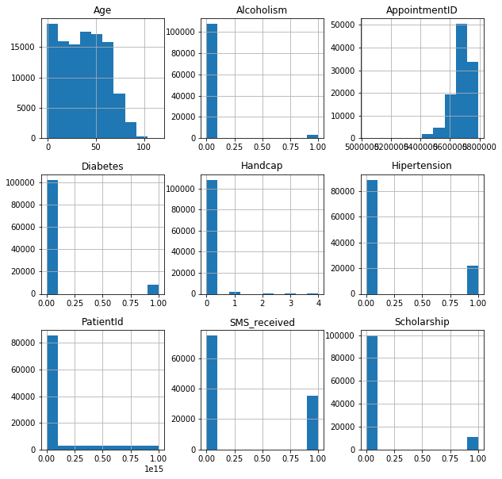

```python
#figure out which columns is suitable to be a variable
all_app.hist(figsize=(10,10));
```

```python
#as AppointmentId is not usefull so will be dropped
all_app.drop(['AppointmentID'], axis=1, inplace=True)
```

```python
#double check
all_app.head(1)
```

|  | PatientId | Gender | ScheduledDay | AppointmentDay | Age | Neighbourhood | Scholarship | Hipertension | Diabetes | Alcoholism | Handcap | SMS_received | No-show |
| --- | --- | --- | --- | --- | --- | --- | --- | --- | --- | --- | --- | --- | --- |
| 0 | 2.987250e+13 | F | 2016-04-29T18:38:08Z | 2016-04-29T00:00:00Z | 62 | JARDIM DA PENHA | 0 | 1 | 0 | 0 | 0 | 0 | No |

```python
#check for repeating PatientId
all_app.duplicated(subset=['PatientId'])
```

```
0         False
1         False
2         False
3         False
4         False
          ...
110522     True
110523     True
110524    False
110525     True
110526     True
Length: 110527, dtype: bool
```

```python
#group by PatientId, Gender and Age
dup_id= all_app[all_app.duplicated(['PatientId','Gender', 'Age'])]
print("Duplicate Rows based on PatientId are:", dup_id, sep='\n')
```

```
Duplicate Rows based on PatientId are:
           PatientId Gender          ScheduledDay        AppointmentDay  Age  \
27      1.215484e+13      F  2016-04-27T10:51:45Z  2016-04-29T00:00:00Z    4
154     1.925263e+10      F  2016-04-28T16:38:34Z  2016-04-29T00:00:00Z   30
288     2.246214e+13      M  2016-03-31T12:39:06Z  2016-04-29T00:00:00Z   43
290     7.222383e+12      M  2016-04-11T09:50:18Z  2016-04-29T00:00:00Z    7
316     1.756579e+13      F  2016-04-14T10:01:09Z  2016-04-29T00:00:00Z    1
...              ...    ...                   ...                   ...  ...
110519  6.542388e+13      F  2016-04-27T15:23:14Z  2016-06-07T00:00:00Z   22
110522  2.572134e+12      F  2016-05-03T09:15:35Z  2016-06-07T00:00:00Z   56
110523  3.596266e+12      F  2016-05-03T07:27:33Z  2016-06-07T00:00:00Z   51
110525  9.213493e+13      F  2016-04-27T15:09:23Z  2016-06-07T00:00:00Z   38
110526  3.775115e+14      F  2016-04-27T13:30:56Z  2016-06-07T00:00:00Z   54

       Neighbourhood  Scholarship  Hipertension  Diabetes  Alcoholism  \
```

[output cut: 26 more lines]

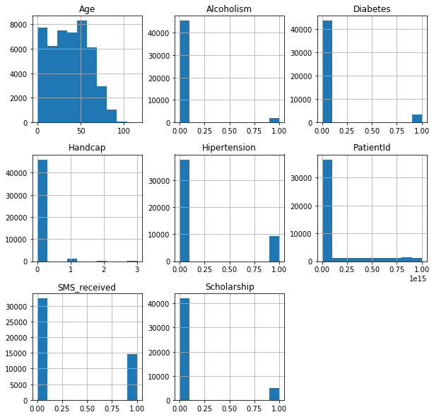

```python
dup_id.hist(figsize=(10,10));
```

```python
all_app.sort_values(['Age'], ascending=True)
```

|  | PatientId | Gender | ScheduledDay | AppointmentDay | Age | Neighbourhood | Scholarship | Hipertension | Diabetes | Alcoholism | Handcap | SMS_received | No-show |
| --- | --- | --- | --- | --- | --- | --- | --- | --- | --- | --- | --- | --- | --- |
| 99832 | 4.659432e+14 | F | 2016-06-06T08:58:13Z | 2016-06-06T00:00:00Z | -1 | ROMÃO | 0 | 0 | 0 | 0 | 0 | 0 | No |
| 34218 | 3.469431e+12 | F | 2016-05-03T06:57:26Z | 2016-05-09T00:00:00Z | 0 | REDENÇÃO | 0 | 0 | 0 | 0 | 0 | 0 | Yes |
| 102834 | 4.882675e+10 | F | 2016-05-04T14:35:59Z | 2016-06-01T00:00:00Z | 0 | MARUÍPE | 0 | 0 | 0 | 0 | 0 | 1 | No |
| 102832 | 9.726846e+12 | F | 2016-05-31T08:19:38Z | 2016-06-01T00:00:00Z | 0 | MARUÍPE | 0 | 0 | 0 | 0 | 0 | 0 | No |
| 102830 | 2.845290e+13 | M | 2016-05-05T11:24:09Z | 2016-06-08T00:00:00Z | 0 | SÃO CRISTÓVÃO | 0 | 0 | 0 | 0 | 0 | 1 | No |
| ... | ... | ... | ... | ... | ... | ... | ... | ... | ... | ... | ... | ... | ... |
| 63915 | 3.196321e+13 | F | 2016-05-16T09:17:44Z | 2016-05-19T00:00:00Z | 115 | ANDORINHAS | 0 | 0 | 0 | 0 | 1 | 0 | Yes |
| 76284 | 3.196321e+13 | F | 2016-05-30T09:44:51Z | 2016-05-30T00:00:00Z | 115 | ANDORINHAS | 0 | 0 | 0 | 0 | 1 | 0 | No |
| 68127 | 3.196321e+13 | F | 2016-04-08T14:29:17Z | 2016-05-16T00:00:00Z | 115 | ANDORINHAS | 0 | 0 | 0 | 0 | 1 | 0 | Yes |
| 63912 | 3.196321e+13 | F | 2016-05-16T09:17:44Z | 2016-05-19T00:00:00Z | 115 | ANDORINHAS | 0 | 0 | 0 | 0 | 1 | 0 | Yes |
| 97666 | 7.482346e+14 | F | 2016-05-19T07:57:56Z | 2016-06-03T00:00:00Z | 115 | SÃO JOSÉ | 0 | 1 | 0 | 0 | 0 | 1 | No |

110527 rows × 13 columns

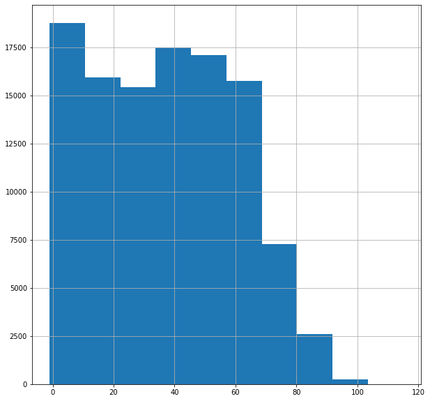

```python
all_app.Age.hist(figsize=(10,10));
```

```python
all_app['Age'].mean()
```

```
37.08887421173107
```

```python
#coulmn Age shows value -1 , it might be indicated for preginant ladies but it will be counfusing during the analysis
# as long it is only one value so it will be removed
all_app.drop(all_app.loc[all_app['Age']<0].index, inplace=True)
```

```python
#double check
all_app.sort_values(['Age'], ascending=True)
```

|  | PatientId | Gender | ScheduledDay | AppointmentDay | Age | Neighbourhood | Scholarship | Hipertension | Diabetes | Alcoholism | Handcap | SMS_received | No-show |
| --- | --- | --- | --- | --- | --- | --- | --- | --- | --- | --- | --- | --- | --- |
| 104654 | 8.822980e+14 | F | 2016-06-02T08:59:43Z | 2016-06-02T00:00:00Z | 0 | MONTE BELO | 0 | 0 | 0 | 0 | 0 | 0 | No |
| 44729 | 3.729549e+12 | M | 2016-04-28T12:44:54Z | 2016-05-03T00:00:00Z | 0 | INHANGUETÁ | 0 | 0 | 0 | 0 | 0 | 0 | No |
| 29671 | 9.997773e+13 | M | 2016-04-29T08:41:15Z | 2016-05-02T00:00:00Z | 0 | SÃO PEDRO | 0 | 0 | 0 | 0 | 0 | 0 | No |
| 42673 | 3.637132e+12 | M | 2016-05-09T10:21:59Z | 2016-05-19T00:00:00Z | 0 | MARIA ORTIZ | 0 | 0 | 0 | 0 | 0 | 0 | No |
| 42674 | 9.728985e+12 | M | 2016-04-18T13:29:49Z | 2016-05-05T00:00:00Z | 0 | JABOUR | 0 | 0 | 0 | 0 | 0 | 1 | No |
| ... | ... | ... | ... | ... | ... | ... | ... | ... | ... | ... | ... | ... | ... |
| 97666 | 7.482346e+14 | F | 2016-05-19T07:57:56Z | 2016-06-03T00:00:00Z | 115 | SÃO JOSÉ | 0 | 1 | 0 | 0 | 0 | 1 | No |
| 68127 | 3.196321e+13 | F | 2016-04-08T14:29:17Z | 2016-05-16T00:00:00Z | 115 | ANDORINHAS | 0 | 0 | 0 | 0 | 1 | 0 | Yes |
| 63912 | 3.196321e+13 | F | 2016-05-16T09:17:44Z | 2016-05-19T00:00:00Z | 115 | ANDORINHAS | 0 | 0 | 0 | 0 | 1 | 0 | Yes |
| 76284 | 3.196321e+13 | F | 2016-05-30T09:44:51Z | 2016-05-30T00:00:00Z | 115 | ANDORINHAS | 0 | 0 | 0 | 0 | 1 | 0 | No |
| 63915 | 3.196321e+13 | F | 2016-05-16T09:17:44Z | 2016-05-19T00:00:00Z | 115 | ANDORINHAS | 0 | 0 | 0 | 0 | 1 | 0 | Yes |

110526 rows × 13 columns

```python
#extract the date from columns ScheduledDay and AppointmentDay
import datetime as dt
all_app['ScheduledDay'] = all_app['ScheduledDay'].apply(lambda x : pd.to_datetime(str(x)))
all_app['Schedule_dates'] = all_app['ScheduledDay'].dt.date
```

```python
#double check
all_app.head(1)
```

|  | PatientId | Gender | ScheduledDay | AppointmentDay | Age | Neighbourhood | Scholarship | Hipertension | Diabetes | Alcoholism | Handcap | SMS_received | No-show | Schedule_dates |
| --- | --- | --- | --- | --- | --- | --- | --- | --- | --- | --- | --- | --- | --- | --- |
| 0 | 2.987250e+13 | F | 2016-04-29 18:38:08+00:00 | 2016-04-29T00:00:00Z | 62 | JARDIM DA PENHA | 0 | 1 | 0 | 0 | 0 | 0 | No | 2016-04-29 |

```python
#drop ScheduledDay column
all_app.drop(['ScheduledDay'], axis=1, inplace=True)
all_app.head(1)
```

|  | PatientId | Gender | AppointmentDay | Age | Neighbourhood | Scholarship | Hipertension | Diabetes | Alcoholism | Handcap | SMS_received | No-show | Schedule_dates |
| --- | --- | --- | --- | --- | --- | --- | --- | --- | --- | --- | --- | --- | --- |
| 0 | 2.987250e+13 | F | 2016-04-29T00:00:00Z | 62 | JARDIM DA PENHA | 0 | 1 | 0 | 0 | 0 | 0 | No | 2016-04-29 |

```python
#repeate the date extraction from column AppointmentDay
all_app['AppointmentDay'] = all_app['AppointmentDay'].apply(lambda x : pd.to_datetime(str(x)))
all_app['Appointment_date'] = all_app['AppointmentDay'].dt.date
```

```python
#double check
all_app.head(1)
```

|  | PatientId | Gender | AppointmentDay | Age | Neighbourhood | Scholarship | Hipertension | Diabetes | Alcoholism | Handcap | SMS_received | No-show | Schedule_dates | Appointment_date |
| --- | --- | --- | --- | --- | --- | --- | --- | --- | --- | --- | --- | --- | --- | --- |
| 0 | 2.987250e+13 | F | 2016-04-29 00:00:00+00:00 | 62 | JARDIM DA PENHA | 0 | 1 | 0 | 0 | 0 | 0 | No | 2016-04-29 | 2016-04-29 |

```python
#drop AppointmentDay column
all_app.drop(['AppointmentDay'], axis=1, inplace=True)
all_app.head(1)
```

|  | PatientId | Gender | Age | Neighbourhood | Scholarship | Hipertension | Diabetes | Alcoholism | Handcap | SMS_received | No-show | Schedule_dates | Appointment_date |
| --- | --- | --- | --- | --- | --- | --- | --- | --- | --- | --- | --- | --- | --- |
| 0 | 2.987250e+13 | F | 62 | JARDIM DA PENHA | 0 | 1 | 0 | 0 | 0 | 0 | No | 2016-04-29 | 2016-04-29 |

```python
all_app.drop(['dates'], axis=1, inplace=True)
```

[output not shown]

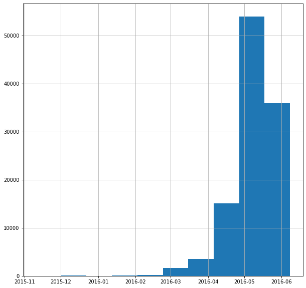

```python
all_app.Schedule_dates.hist(figsize=(10,10));
```

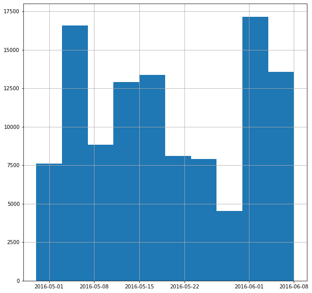

```python
all_app.Appointment_date.hist(figsize=(10,10));
```

```python
# How many Neighbourhood are there
all_app['Neighbourhood'].value_counts()
```

```
JARDIM CAMBURI                 7717
MARIA ORTIZ                    5805
RESISTÊNCIA                    4431
JARDIM DA PENHA                3877
ITARARÉ                        3514
                               ...
ILHA DO BOI                      35
ILHA DO FRADE                    10
AEROPORTO                         8
ILHAS OCEÂNICAS DE TRINDADE       2
PARQUE INDUSTRIAL                 1
Name: Neighbourhood, Length: 81, dtype: int64
```

```python
# rename No-show to NO_show
all_app.rename(columns={"No-show":"NO_show"}, inplace=True)
```

```python
# replace by lowercase labels for the dataset
all_app.rename(columns=lambda x: x.strip().lower(), inplace=True)
# confirm changes
all_app.head(1)
```

|  | patientid | gender | age | neighbourhood | scholarship | hipertension | diabetes | alcoholism | handcap | sms_received | no_show | schedule_dates | appointment_date |
| --- | --- | --- | --- | --- | --- | --- | --- | --- | --- | --- | --- | --- | --- |
| 0 | 2.987250e+13 | F | 62 | JARDIM DA PENHA | 0 | 1 | 0 | 0 | 0 | 0 | No | 2016-04-29 | 2016-04-29 |

#### As long the number of variables in Neighbourhood is not limited to small amount so we can not use the coulmn as a dependend variable

### Research Question 1 : is the Age a main parameter can be used to determine the reason of absence in the appointment?

```python
# creat bining function to input a new cut_points for age columns
# will insert the min and mx of age then use cut function of pandas
def binning(col, age_limit, labels=None):
    minimum = col.min()
    maximum = col.max()
    break_points = [minimum] + cut_points + [maximum]
    age_bin= pd.cut(col,bins=break_points,labels=labels,include_lowest=True)
    return age_bin

#the age limit for bins:
age_limit = [10, 20, 30, 40, 50, 60, 70, 80, 90, 100]
labels = ["babys_and_ schoolchild","teenager","young_adult","40-49_years_old", "50-59_years_old", "60-69_years_old", "70-79_years_old", "80-89_years_old", "90-99_years_old", "100-109_years_old", "110_years_old"]
all_app["age_Bin"] = binning(all_app["age"], age_limit, labels)
print(pd.value_counts(all_app["age_Bin"], sort=False))
```

[output not shown]

```python
all_app['no_show'].value_counts()
```

```
No     88207
Yes    22319
Name: no_show, dtype: int64
```

```python
all_app.groupby(["no_show", "age"]).size()
```

```
no_show  age
No       0      2900
         1      1858
         2      1366
         3      1236
         4      1017
                ...
Yes      95        6
         96        1
         97        2
         98        1
         115       3
Length: 203, dtype: int64
```

```python
all_app.groupby(["no_show", "age"]).describe()
```

| no_show | age | patientid count | patientid mean | patientid std | patientid min | patientid 25% | patientid 50% | patientid 75% | patientid max | scholarship count | scholarship mean | ... | handcap 75% | handcap max | sms_received count | sms_received mean | sms_received std | sms_received min | sms_received 25% | sms_received 50% | sms_received 75% | sms_received max |
| --- | --- | --- | --- | --- | --- | --- | --- | --- | --- | --- | --- | --- | --- | --- | --- | --- | --- | --- | --- | --- | --- | --- |
| No | 0 | 2900.0 | 1.553250e+14 | 2.652446e+14 | 2.699191e+08 | 4.214987e+12 | 3.293970e+13 | 9.651290e+13 | 9.975547e+14 | 2900.0 | 0.015517 | ... | 0.0 | 1.0 | 2900.0 | 0.234828 | 0.423964 | 0.0 | 0.0 | 0.0 | 0.0 | 1.0 |
|  | 1 | 1858.0 | 1.602993e+14 | 2.645510e+14 | 8.688158e+08 | 4.617882e+12 | 3.666356e+13 | 9.953797e+13 | 9.999816e+14 | 1858.0 | 0.037675 | ... | 0.0 | 1.0 | 1858.0 | 0.201830 | 0.401474 | 0.0 | 0.0 | 0.0 | 0.0 | 1.0 |
|  | 2 | 1366.0 | 1.401013e+14 | 2.446478e+14 | 9.528125e+08 | 4.672325e+12 | 3.524162e+13 | 9.228827e+13 | 9.926833e+14 | 1366.0 | 0.076135 | ... | 0.0 | 1.0 | 1366.0 | 0.193997 | 0.395571 | 0.0 | 0.0 | 0.0 | 0.0 | 1.0 |
|  | 3 | 1236.0 | 1.441559e+14 | 2.454818e+14 | 8.799645e+07 | 4.417099e+12 | 3.232041e+13 | 9.518368e+13 | 9.942356e+14 | 1236.0 | 0.090615 | ... | 0.0 | 0.0 | 1236.0 | 0.233010 | 0.422919 | 0.0 | 0.0 | 0.0 | 0.0 | 1.0 |
|  | 4 | 1017.0 | 1.493441e+14 | 2.639227e+14 | 4.815435e+08 | 4.524759e+12 | 2.845560e+13 | 8.767217e+13 | 9.981913e+14 | 1017.0 | 0.118977 | ... | 0.0 | 2.0 | 1017.0 | 0.249754 | 0.433084 | 0.0 | 0.0 | 0.0 | 0.0 | 1.0 |
| ... | ... | ... | ... | ... | ... | ... | ... | ... | ... | ... | ... | ... | ... | ... | ... | ... | ... | ... | ... | ... | ... | ... |
| Yes | 95 | 6.0 | 1.483718e+14 | 2.407792e+14 | 9.828640e+12 | 4.842329e+13 | 4.842329e+13 | 8.610331e+13 | 6.364690e+14 | 6.0 | 0.000000 | ... | 1.0 | 1.0 | 6.0 | 0.500000 | 0.547723 | 0.0 | 0.0 | 0.5 | 1.0 | 1.0 |
|  | 96 | 1.0 | 7.374252e+12 | NaN | 7.374252e+12 | 7.374252e+12 | 7.374252e+12 | 7.374252e+12 | 7.374252e+12 | 1.0 | 0.000000 | ... | 0.0 | 0.0 | 1.0 | 0.000000 | NaN | 0.0 | 0.0 | 0.0 | 0.0 | 0.0 |
|  | 97 | 2.0 | 4.659795e+14 | 6.514511e+14 | 5.333970e+12 | 2.356567e+14 | 4.659795e+14 | 6.963022e+14 | 9.266250e+14 | 2.0 | 0.000000 | ... | 0.0 | 0.0 | 2.0 | 0.000000 | 0.000000 | 0.0 | 0.0 | 0.0 | 0.0 | 0.0 |
|  | 98 | 1.0 | 1.294694e+14 | NaN | 1.294694e+14 | 1.294694e+14 | 1.294694e+14 | 1.294694e+14 | 1.294694e+14 | 1.0 | 0.000000 | ... | 0.0 | 0.0 | 1.0 | 0.000000 | NaN | 0.0 | 0.0 | 0.0 | 0.0 | 0.0 |
|  | 115 | 3.0 | 3.196321e+13 | 0.000000e+00 | 3.196321e+13 | 3.196321e+13 | 3.196321e+13 | 3.196321e+13 | 3.196321e+13 | 3.0 | 0.000000 | ... | 1.0 | 1.0 | 3.0 | 0.000000 | 0.000000 | 0.0 | 0.0 | 0.0 | 0.0 | 0.0 |

203 rows × 56 columns

```python
age_show= all_app[["no_show","age"]].groupby("no_show")
age_show.describe()
```

| no_show | age count | age mean | age std | age min | age 25% | age 50% | age 75% | age max |
| --- | --- | --- | --- | --- | --- | --- | --- | --- |
| No | 88207.0 | 37.790504 | 23.338645 | 0.0 | 18.0 | 38.0 | 56.0 | 115.0 |
| Yes | 22319.0 | 34.317667 | 21.965941 | 0.0 | 16.0 | 33.0 | 51.0 | 115.0 |

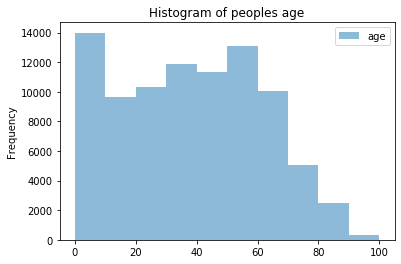

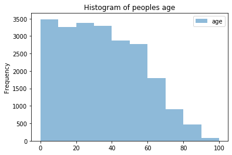

```python
#plot the absence group and attended group related to the age
age_show.plot.hist(title=('Histogram of peoples age'),range = (0,100), alpha=0.5);
```

[figure not shown]

```python
#plot the absence group and attended group related to the age
ax = all_app['age'].plot(kind='hist')
ax.set_xticks(cut_points)
ax.set_xticklabels(labels, rotation= 60, )

plt.xlabel('Age Classification', fontsize= 16)
plt.ylabel('Number of Patients', fontsize=16)
plt.title('Number of "Absence" Patients by Age Group', fontsize=22)
plt.xlim([0, 120])

plt.show()
```

### Research Question 2 : is the date of scheduling the appointment so close to the appointment date?

```python
#to find the different between schedule_dates and appointment_date for each sample
#will create 2 columns to do all the operation on them A and B
all_app['A'] = pd.to_datetime(all_app['schedule_dates'])
all_app['B'] = pd.to_datetime(all_app['appointment_date'])
all_app.dtypes
```

```
patientid                  float64
gender                      object
age                          int64
neighbourhood               object
scholarship                  int64
hipertension                 int64
diabetes                     int64
alcoholism                   int64
handcap                      int64
sms_received                 int64
no_show                     object
schedule_dates              object
appointment_date            object
A                   datetime64[ns]
B                   datetime64[ns]
dtype: object
```

```python
date_diff= all_app['B'] - all_app['A']
```

```python
date_diff.describe()
```

```
count                     110526
mean     10 days 04:24:39.789370
std      15 days 06:07:14.979140
min            -6 days +00:00:00
25%              0 days 00:00:00
50%              4 days 00:00:00
75%             15 days 00:00:00
max            179 days 00:00:00
dtype: object
```

```python
date_diff.value_counts()
```

```
0 days      38562
2 days       6725
4 days       5290
1 days       5213
7 days       4906
            ...
139 days        1
123 days        1
146 days        1
-6 days         1
132 days        1
Length: 131, dtype: int64
```

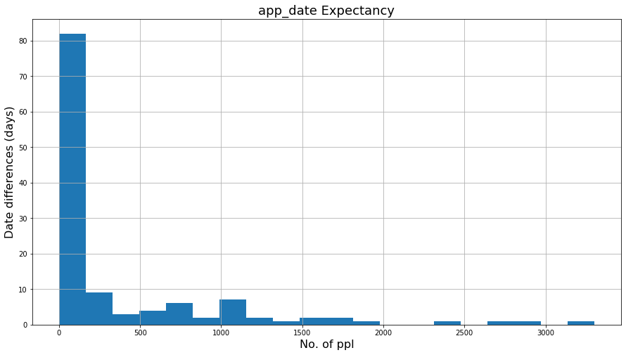

```python
date_diff.value_counts().hist(figsize=(15,8), bins=20, range=(0,3300));
plt.title('app_date Expectancy', fontsize=18)
plt.xlabel('No. of ppl', fontsize=16)
plt.ylabel('Date differences (days)', fontsize=16);
```

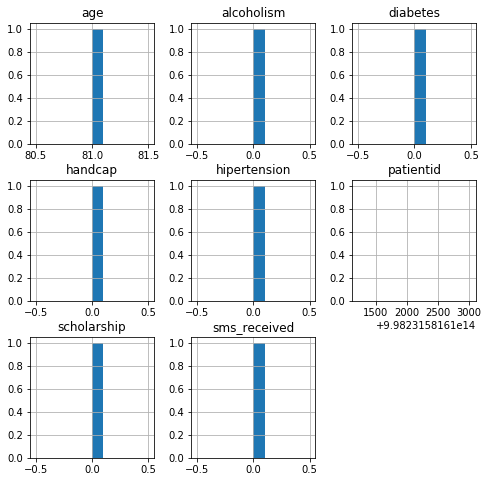

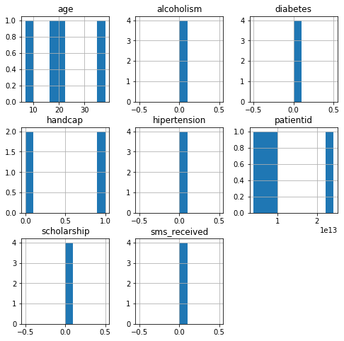

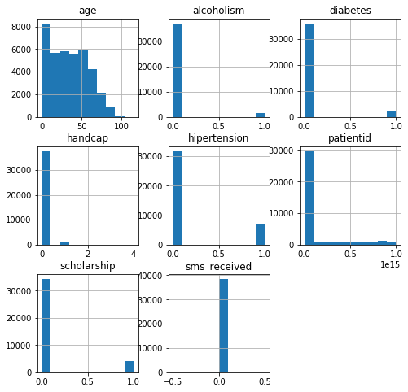

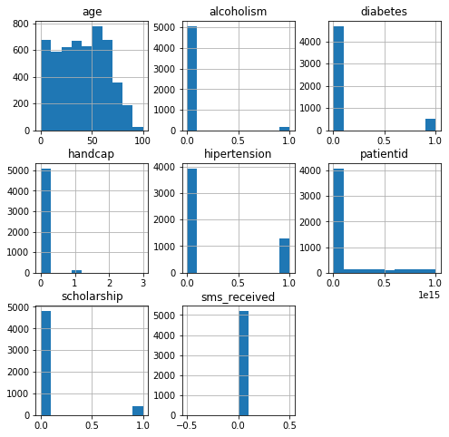

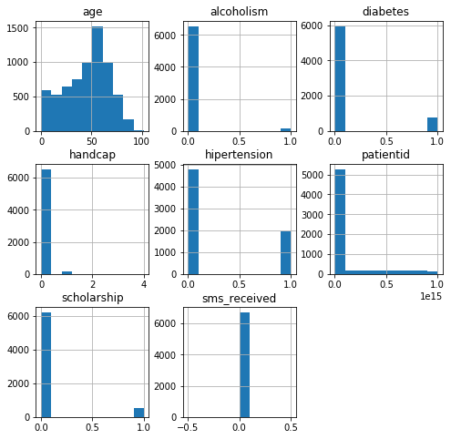

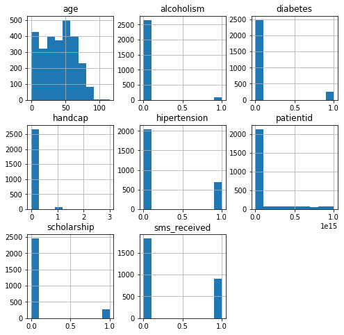

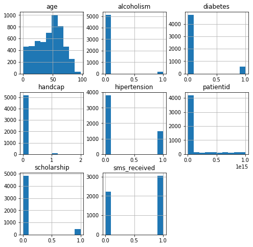

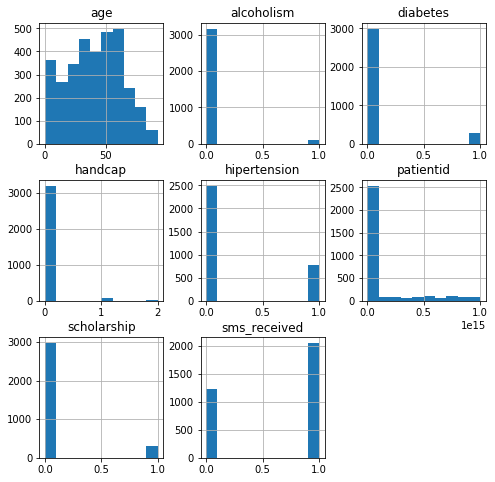

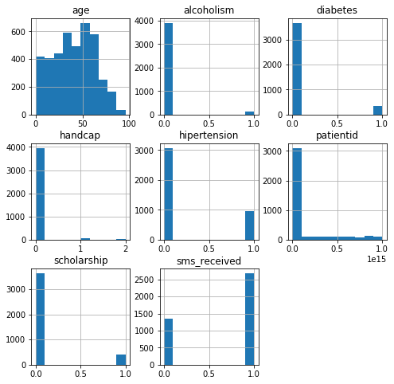

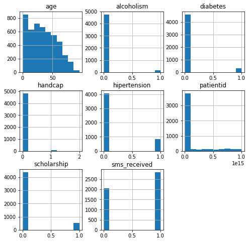

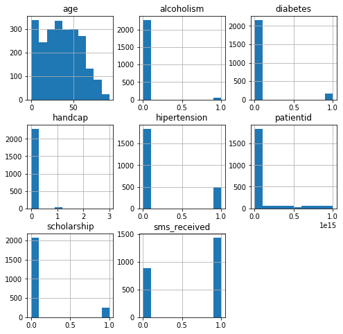

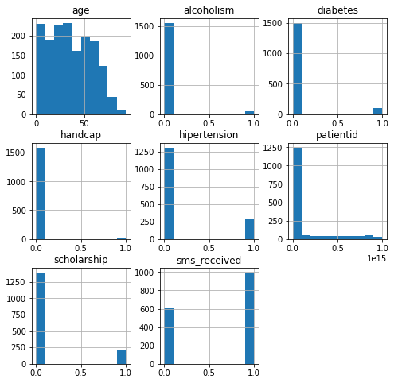

[119 more figures not shown]

```python
#summerise the people whom recieved the appointment date before it by 15 days
date_show_75= all_app.groupby(date_diff)
date_show_75.hist(figsize=(8,8));
```